# SALT Larval Consensus Summary Statistics

#### By Dexter Davis - Research Technician for Dr. Shawn Arellano

#### This Markdown file summarizes the larval data collected with the SyPRID collector on the AUV Sentry during the 2020 EN658 and 2021 TN391 SALT project cruises.

#### This markdown file will summarize the data by site as well as by depth classification. Depth classification are as follows: Demersal - 5 meters above bottom, Thermocline depths varied between sites, Mid Water Column was a midway depth between the thermocline and demersal depths.

#### **Data Entry and Subsetting**

```r
#install.packages("ggplot2")
library(PNWColors)
library(ggplot2)
library(readxl)
library(knitr)
library(RColorBrewer)
library(gplots)
library(qrcode)

setwd("C:/Users/davis/OneDrive/Desktop/SPMC Work/Morphotype Consensus")

## Every Dive from Both Cruises
Dive <- read_xlsx("SALT_Larval_Consensus_Final_COPY.xlsx", sheet = "Larval Total Counts")
Dive <- Dive[-c(43),]
Dive <- subset(Dive[-c(7:153)])

## Number of Dives per Site and Depth Classification
Dives <- read_xlsx("SALT_Larval_Consensus_Final_COPY.xlsx", sheet = "Number of Dives")
SiteD <- subset(Dives[-c(1:3)])
colnames(SiteD) <- c("Site","Number of Dives","Average Flow Rate (L/min)")
DepthD <-subset(Dives[-c(4:6)])
DepthD <- na.omit(DepthD)
colnames(DepthD) <- c("Depth Classification","Number of Dives","Average Flow Rate (L/min)")


## Average Volume Collected, Larvae Collected, Larval Density per Site and Depth Classification
Avgs <- read_xlsx("SALT_Larval_Consensus_Final_COPY.xlsx", sheet = "Averages")
SiteAvg <- subset(Avgs[-c(8:15)])
SVol <- subset(SiteAvg[-c(4:7)])
SLar <- subset(SiteAvg[-c(2:3,6:7)])
SDen <- subset(SiteAvg[-c(2:5)])
SDen <- subset(SDen, SDen$Site != "Florida Keys")

DepthAvg <- subset(Avgs[-c(1:8)])
DepthAvg <- na.omit(DepthAvg)
DVol <- subset(DepthAvg[-c(4:7)])
DLar <- subset(DepthAvg[-c(2:3,6:7)])
DDen <- subset(DepthAvg[-c(2:5)])

## Site data untouched - has each site and depth classifications within
Site <- read_xlsx("SALT_Larval_Consensus_Final_COPY.xlsx", sheet = "Larval Density by Site an Depth")
BaltimoreCanyon <- subset(Site,Site$`Sample Site`=="Baltimore Canyon")
BlakeRidge <- subset(Site,Site$`Sample Site`=="Blake Ridge")
BrinePool <- subset(Site,Site$`Sample Site`=="Brine Pool")
BushHill <- subset(Site,Site$`Sample Site`=="Bush Hill")
Chincoteague <- subset(Site,Site$`Sample Site`=="Chincoteague")
FloridaEscarpment <- subset(Site,Site$`Sample Site`=="Florida Escarpment")
GC234 <- subset(Site,Site$`Sample Site`=="Green Canyon 234")
MississippiCanyon <- subset(Site,Site$`Sample Site`=="Mississippi Canyon")

## Larval Type Code Guide
Guide <- read_xlsx("SALT_Larval_Consensus_Final_COPY.xlsx", sheet ="Larval Type Guide")

## Larval Type Presence by Depth
LarvDepth <- read_xlsx("SALT_Larval_Consensus_Final_COPY.xlsx", sheet ="Larval Type by Depth")

LDDem <- subset(LarvDepth,LarvDepth$`Depth Classification`=="Demersal")
LDDem <- subset(LDDem[-c(1)])
LDMWC <- subset(LarvDepth,LarvDepth$`Depth Classification`=="Mid Water Column")
LDMWC <- subset(LDMWC[-c(1)])
LDTherm <- subset(LarvDepth,LarvDepth$`Depth Classification`=="Thermocline")
LDTherm <- subset(LDTherm[-c(1)])
```

## **Summary of Dives from EN658 and TN391**

## ~~~~~~~~~~~~~~~~~~~~~~~~~~~~~~~~~~~~~~~~~~~~~~

| Cruise | Site | Dive # / Code | Method | Depth (meters, mab= meters above bottom) | Depth Classification |
| --- | --- | --- | --- | --- | --- |
| EN658 | Baltimore Canyon | HN0 | Hand Net | 0 | Surface |
| EN658 | Baltimore Canyon | HN200 | Hand Net | 0-200 | Upper Water Column |
| EN658 | Baltimore Canyon | HN200B | Hand Net | 0-200 | Upper Water Column |
| EN658 | Blake Ridge | S569P | Sentry | 5mab | Demersal |
| EN658 | Blake Ridge | S569S | Sentry | 80mab | Lower Water Column |
| EN658 | Blake Ridge | S570S | Sentry | 5-195mab | Lower Water Column |
| EN658 | Blake Ridge | BR200 | Hand Net | 0-200 | Upper Water Column |
| EN658 | Blake Ridge | BR200B | Hand Net | 0-200 | Upper Water Column |
| EN658 | Brine Pool | S572S | Sentry | 5mab | Demersal |
| EN658 | Brine Pool | S572P | Sentry | 80mab | Mid Water Column |
| EN658 | Brine Pool | BP200 | Hand Net | 0-200 | Upper Water Column |
| EN658 | Brine Pool | BP200B | Hand Net | 0-200 | Upper Water Column |
| EN658 | Bush Hill | BH200B | Hand Net | 0-200 | Upper Water Column |
| EN658 | Bush Hill | BH200C | Hand Net | 0-200 | Upper Water Column |
| EN658 | Florida Keys | FK200 | Hand Net | 0-200 | Upper Water Column |
| EN658 | Florida Keys | FK200B | Hand Net | 0-200 | Upper Water Column |
| EN658 | Mississippi Canyon | MC200 | Hand Net | 0-200 | Upper Water Column |
| EN658 | Mississippi Canyon | MC200B | Hand Net | 0-200 | Upper Water Column |
| TN391 | Baltimore Canyon | S583P | Sentry | 10mab (420) | Demersal |
| TN391 | Baltimore Canyon | S584P | Sentry | 5mab (425) | Demersal |
| TN391 | Baltimore Canyon | S585P | Sentry | 5mab (380) | Demersal |
| TN391 | Baltimore Canyon | S584S | Sentry | 300 | Mid Water Column |
| TN391 | Baltimore Canyon | S583S | Sentry | 200 | Thermocline |
| TN391 | Blake Ridge | S587P | Sentry | 5mab (2160) | Demersal |
| TN391 | Blake Ridge | S588P | Sentry | 5mab (2163) | Demersal |
| TN391 | Blake Ridge | S587S | Sentry | 200 | Thermocline |
| TN391 | Blake Ridge | S588S | Sentry | 200 | Thermocline |
| TN391 | Brine Pool | S592P | Sentry | 5mab (500) | Demersal |
| TN391 | Brine Pool | S593P | Sentry | 5mab | Demersal |
| TN391 | Brine Pool | S592S | Sentry | 300 | Mid Water Column |
| TN391 | Brine Pool | S593S | Sentry | 200 | Thermocline |
| TN391 | Bush Hill | S594P | Sentry | 5mab | Demersal |
| TN391 | Bush Hill | S594S | Sentry | 300 | Mid Water Column |
| TN391 | Chincoteague | S586P | Sentry | 5mab (995) | Demersal |
| TN391 | Florida Escarpment | S589P | Sentry | 5mab (3300) | Demersal |
| TN391 | Florida Escarpment | S590S | Sentry | 1700 | Mid Water Column |
| TN391 | Florida Escarpment | S589S | Sentry | 200 | Thermocline |
| TN391 | Florida Keys | HN200FK | Hand Net | 200 | Surface |
| TN391 | Green Canyon 234 | S591P | Sentry | 5mab (500) | Demersal |
| TN391 | Green Canyon 234 | S591S | Sentry | 300 | Mid Water Column |
| TN391 | Mississippi Canyon | S595P | Sentry | 5mab | Demersal |
| TN391 | Mississippi Canyon | S595S | Sentry | 600 | Mid Water Column |

#### The rest of this markdown file and data analysis will focus only on the TN391 Sentry dives (this exludes Florida Keys Hand Net) and the EN658 Brine Pool Sentry dives (S572S/S572P). Brine Pool was the only EN658 site that had comparable depths to TN391, and Sentry did not malfunction (EN658 Blake Ridge).

# **Sentry Performance**

## **Summary Tables of Number of Dives**

## ~~~~~~~~~~~~~~~~~~~~~~~~~~~~~~~~~~~~~~~~~~~~~~

Number of Dives per Site

| Site | Number of Dives | Average Flow Rate (L/min) |
| --- | --- | --- |
| Baltimore Canyon | 5 | 11521.929 |
| Blake Ridge | 4 | 10900.721 |
| Brine Pool | 5 | 12619.784 |
| Bush Hill | 2 | 9334.150 |
| Chincoteague | 1 | 11569.161 |
| Florida Escarpment | 3 | 12849.621 |
| Green Canyon 234 | 2 | 11067.122 |
| Mississippi Canyon | 2 | 9261.488 |

### Flow Rate Range: 9,261-12,850 Liters/min

Number of Dives per Depth Classification

| Depth Classification | Number of Dives | Average Flow Rate (L/min) |
| --- | --- | --- |
| Demersal | 13 | 8673.924 |
| Mid Water Column | 6 | 10489.760 |
| Thermocline | 5 | 19611.084 |

### Flow Rate Range: 8,674-19,611 Liters/min

## **Statistics Between Sites and Depth Classifications**

## ~~~~~~~~~~~~~~~~~~~~~~~~~~~~~~~~~~~~~~~~~~~~~~

### Sites

#### Volume Sampled

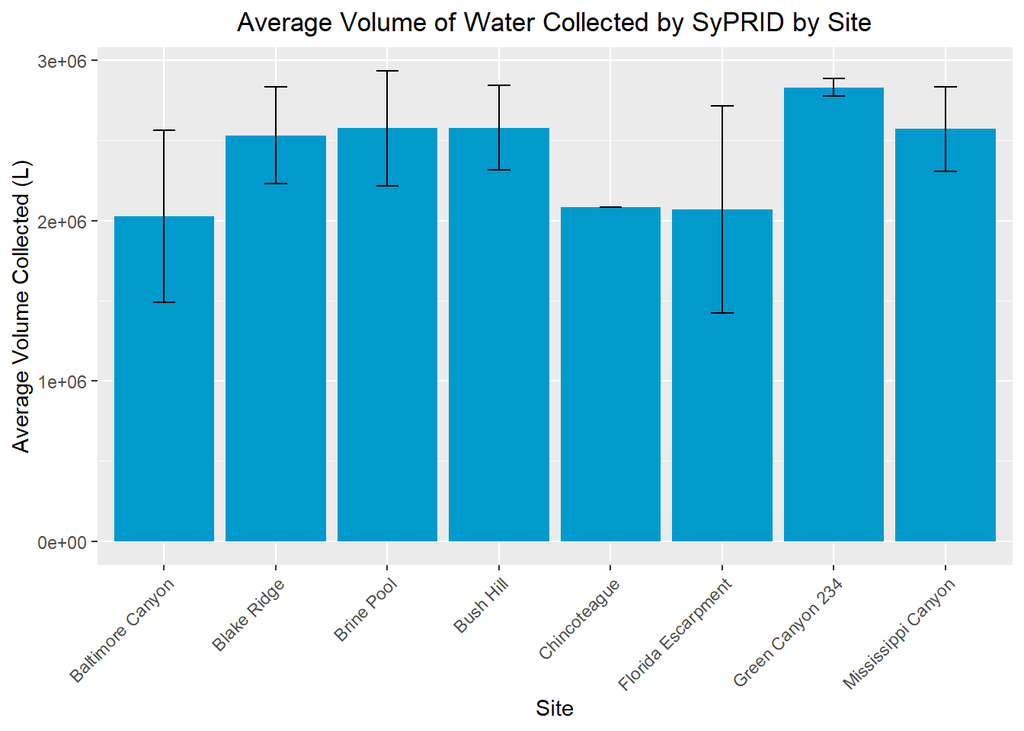

```r
#SVol
my_title <- "Average Volume of Water Collected by SyPRID by Site"
ggplot(SVol, aes(x=SVol$Site, y=SVol$`Avg Volume Sampled`))+geom_bar(fill="deepskyblue3",stat="identity",position=position_dodge(),width = 0.9)+labs(title =my_title, x="Site", y="Average Volume Collected (L)")+theme(plot.title = element_text(hjust=0.5), axis.text.x=element_text(angle = 45, vjust = 1, hjust=1))+geom_errorbar(aes(ymin=SVol$`Avg Volume Sampled`- SVol$`Volume STDev...3`, ymax=SVol$`Avg Volume Sampled`+ SVol$`Volume STDev...3`), width=.2,position=position_dodge(.9))
```

#### Larvae Collected

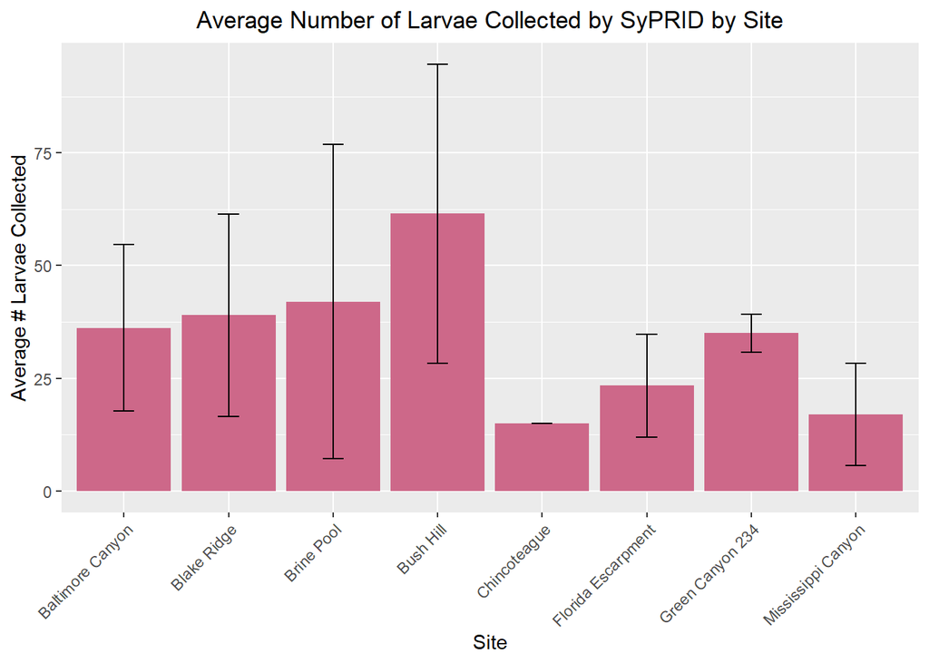

```r
#SLAr
my_title <- "Average Number of Larvae Collected by SyPRID by Site"
ggplot(SLar, aes(x=SLar$Site, y=SLar$`Avg #Larva Collected`))+geom_bar(fill="palevioletred3",stat="identity",position=position_dodge(),width = 0.9)+labs(title =my_title, x="Site", y="Average # Larvae Collected")+theme(plot.title = element_text(hjust=0.5), axis.text.x=element_text(angle = 45, vjust = 1, hjust=1))+geom_errorbar(aes(ymin=SLar$`Avg #Larva Collected`- SLar$`Larvae STDev...5`, ymax=SLar$`Avg #Larva Collected`+SLar$`Larvae STDev...5`), width=.2,position=position_dodge(.9))
```

#### Larval Density

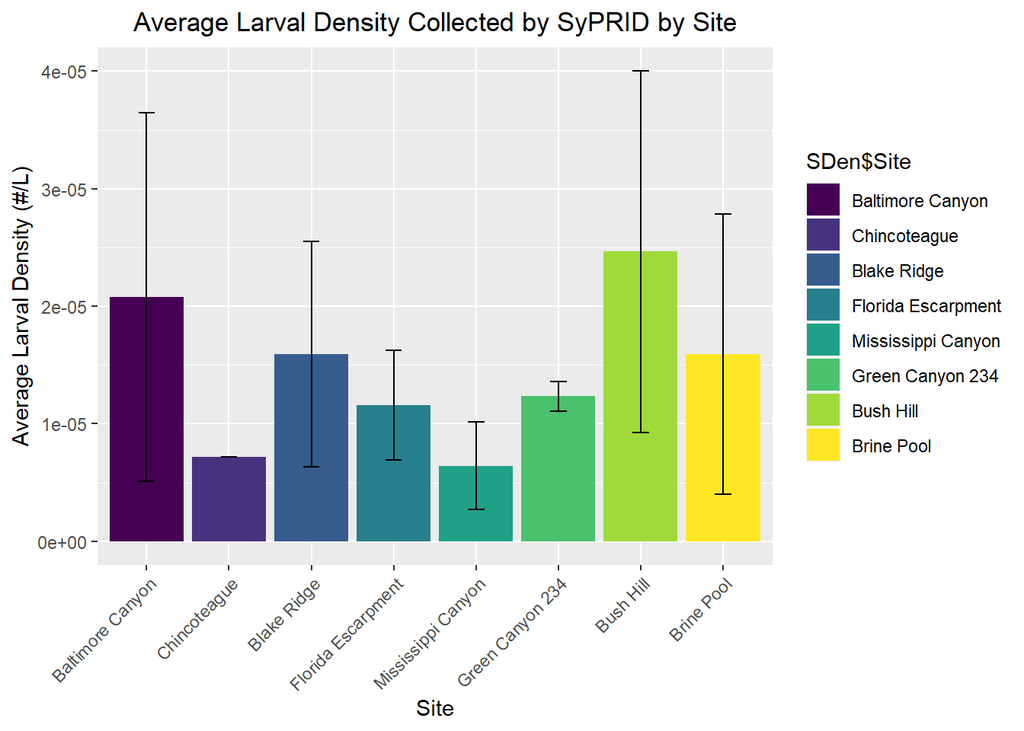

```r
#SDen
SDen$Site <- factor(SDen$Site,levels=c("Baltimore Canyon","Chincoteague","Blake Ridge","Florida Escarpment","Mississippi Canyon","Green Canyon 234","Bush Hill","Brine Pool"))

my_title <- "Average Larval Density Collected by SyPRID by Site"
ggplot(SDen, aes(x=SDen$Site, y=SDen$`Avg Larval Density`,fill=SDen$Site))+geom_bar(stat="identity",position=position_dodge(),width = 0.9)+labs(title =my_title, x="Site", y="Average Larval Density (#/L)")+theme(plot.title = element_text(hjust=0.5), axis.text.x=element_text(angle = 45, vjust = 1, hjust=1))+geom_errorbar(aes(ymin=SDen$`Avg Larval Density`- SDen$`Density STDev...7`, ymax=SDen$`Avg Larval Density`+SDen$`Density STDev...7`), width=.2,position=position_dodge(.9))+scale_fill_viridis_d()
```

### Depth Classifications

#### Volume Sampled

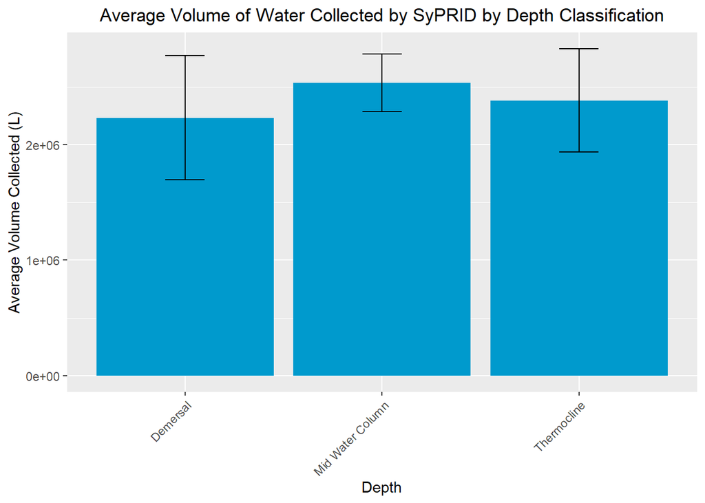

```r
#DVol
my_title <- "Average Volume of Water Collected by SyPRID by Depth Classification"
ggplot(DVol, aes(x=DVol$`Depth Classification`, y=DVol$`Avg. Volume Sampled (L)`))+geom_bar(fill="deepskyblue3",stat="identity",position=position_dodge(),width = 0.9)+labs(title =my_title, x="Depth", y="Average Volume Collected (L)")+theme(plot.title = element_text(hjust=0.5), axis.text.x=element_text(angle = 45, vjust = 1, hjust=1))+geom_errorbar(aes(ymin=DVol$`Avg. Volume Sampled (L)`- DVol$`Volume STDev...11`, ymax=DVol$`Avg. Volume Sampled (L)`+ DVol$`Volume STDev...11`), width=.2,position=position_dodge(.9))
```

#### Larvae Collected

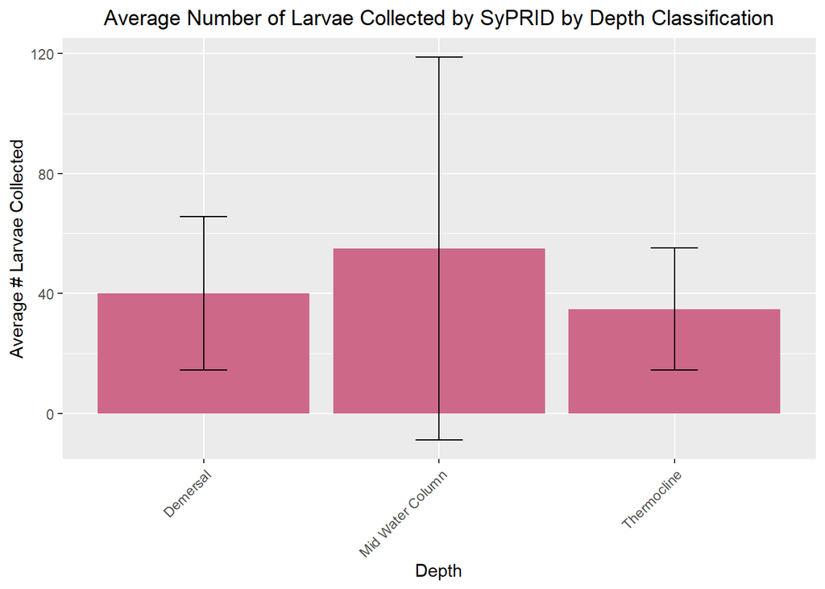

```r
#DLar
my_title <- "Average Number of Larvae Collected by SyPRID by Depth Classification"
ggplot(DLar, aes(x=DLar$`Depth Classification`, y=DLar$`Avg. Larvae Collected`))+geom_bar(fill="palevioletred3",stat="identity",position=position_dodge(),width = 0.9)+labs(title =my_title, x="Depth", y="Average # Larvae Collected")+theme(plot.title = element_text(hjust=0.5), axis.text.x=element_text(angle = 45, vjust = 1, hjust=1))+geom_errorbar(aes(ymin=DLar$`Avg. Larvae Collected`- DLar$`Larvae STDev...13`, ymax=DLar$`Avg. Larvae Collected`+DLar$`Larvae STDev...13`), width=.2,position=position_dodge(.9))
```

#### Larval Density

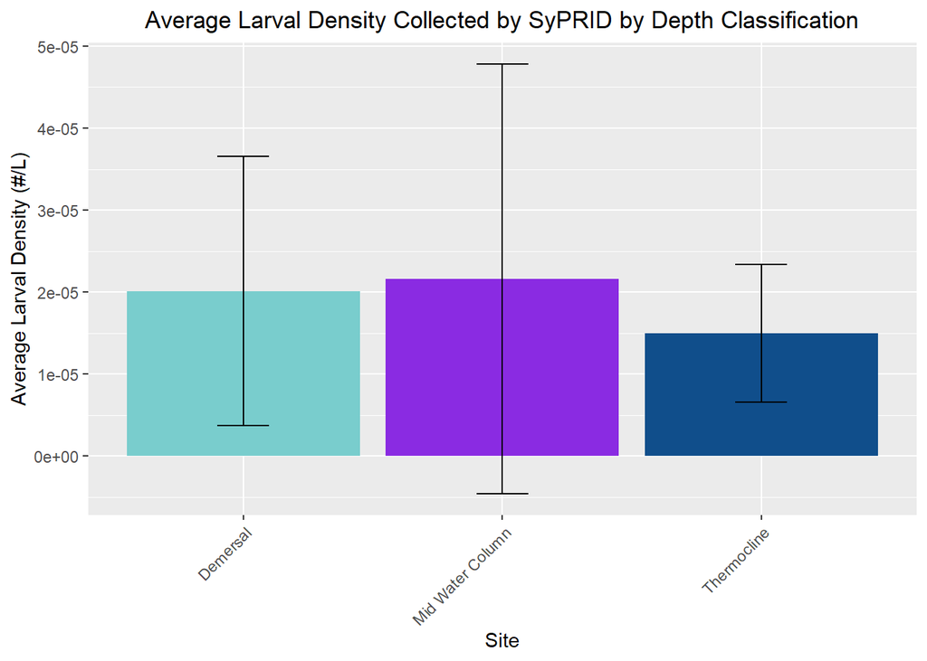

```r
#DDen
my_title <- "Average Larval Density Collected by SyPRID by Depth Classification"
ggplot(DDen, aes(x=DDen$`Depth Classification`, y=DDen$`Avg. Larval Density (#/L)`))+geom_bar(fill=c("darkslategray3","blueviolet","dodgerblue4"),stat="identity",position=position_dodge(),width = 0.9)+labs(title =my_title, x="Site", y="Average Larval Density (#/L)")+theme(plot.title = element_text(hjust=0.5), axis.text.x=element_text(angle = 45, vjust = 1, hjust=1))+geom_errorbar(aes(ymin=DDen$`Avg. Larval Density (#/L)`- DDen$`Density STDev...15`, ymax=DDen$`Avg. Larval Density (#/L)`+DDen$`Density STDev...15`), width=.2,position=position_dodge(.9))
```

## **Statistics Within Individual Sites**

## ~~~~~~~~~~~~~~~~~~~~~~~~~~~~~~~~~~~~~~~~~~~~~~

For sites that had multiple dives at given depths (ex. 3 Demersal depths at Brine Pool), the values were averaged resulting in one bar per depth per site.

```r
#Let's make some fuctions!

wrapper <- function(x, ...)
{
  paste(strwrap(x, ...), collapse = "\n")
}

#Volume Sampled
Vol <- function(site,title){
  ggplot(site, aes(x=`Depth Classification`,y=`Volume Sampled (L)`))+geom_bar(stat="identity", fill='deepskyblue3')+theme(axis.text.x = element_text(angle = 45, vjust = 1, hjust=1))+labs(title=paste0('Volume Sampled with SyPRID by Depth Classificiation at ',title),x="Depth Classificiation", y="Volume Sampled (L)")+theme(plot.title = element_text(hjust = 0.5))
}

#Larvae Collected
Lar <- function(site,title){
  ggplot(site, aes(x=`Depth Classification`,y=`Total Larva Collected`))+geom_bar(stat="identity", fill='palevioletred3')+theme(axis.text.x = element_text(angle = 45, vjust = 1, hjust=1))+labs(title=paste0('Larvae Collected with SyPRID by Depth Classification at ',title),x="Depth Classificiation", y="Number of Larvae")+theme(plot.title = element_text(hjust = 0.5))
}

#Larval Density
Den <- function(site,title){
  my_title <- paste0('Larval Density collected with SyPRID by Depth Classification at ',title)
  ggplot(site, aes(x=`Depth Classification`,y=`Larval Density (#/L)`))+geom_bar(stat="identity", fill='salmon2')+theme(axis.text.x = element_text(angle = 45, vjust = 1, hjust=1))+labs(title=my_title ,x="Depth Classificiation", y="Larval Density (#/L)")+theme(plot.title = element_text(hjust = 0.5))+ggtitle(wrapper(my_title, width = 70))
}
```

### Baltimore Canyon

#### Volume Sampled

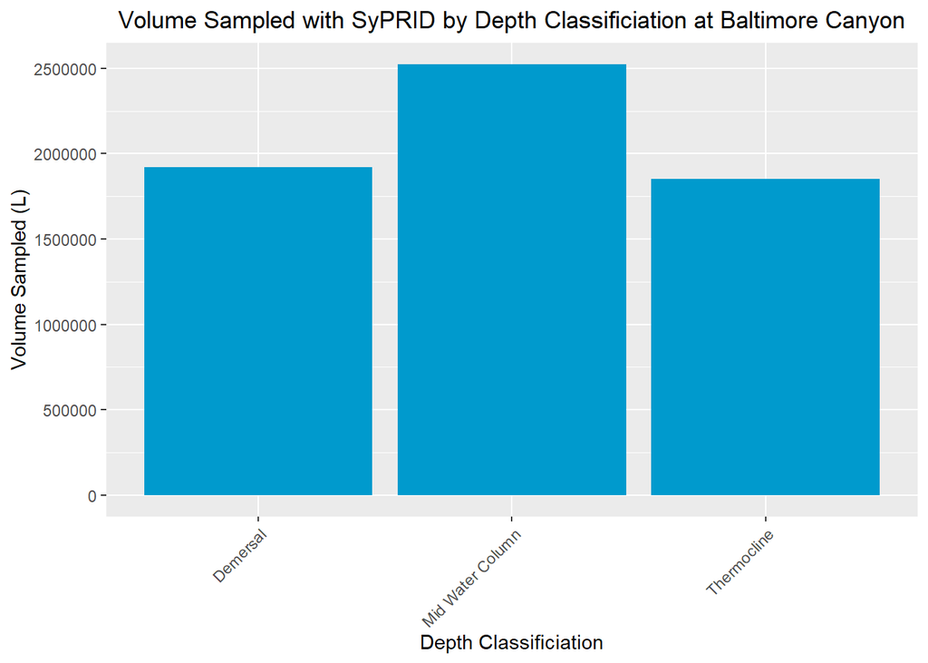

```r
Vol(BaltimoreCanyon,"Baltimore Canyon")
```

#### Larvae Collected

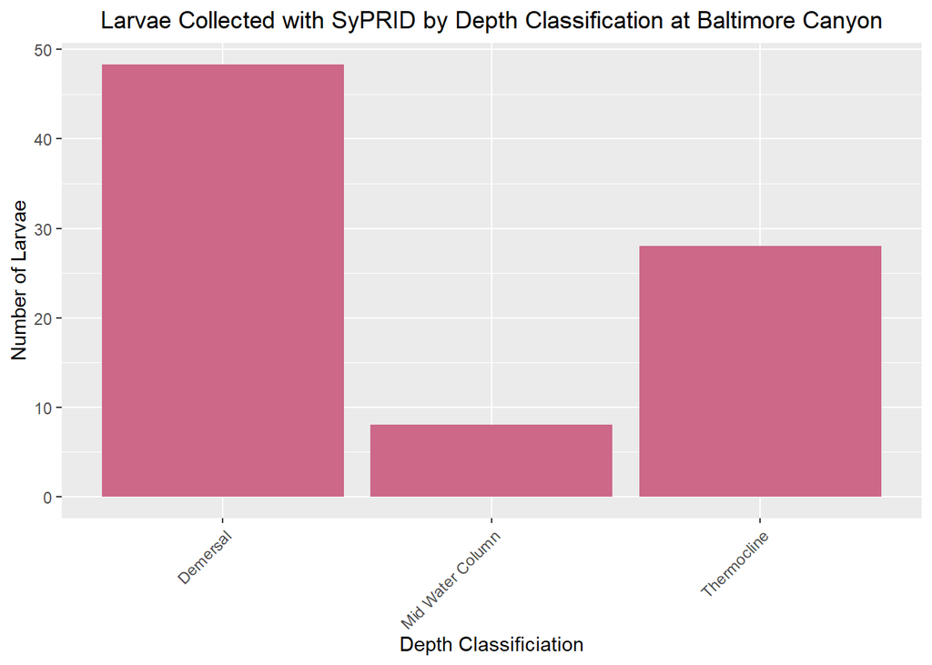

```r
Lar(BaltimoreCanyon,"Baltimore Canyon")
```

#### Larval Density

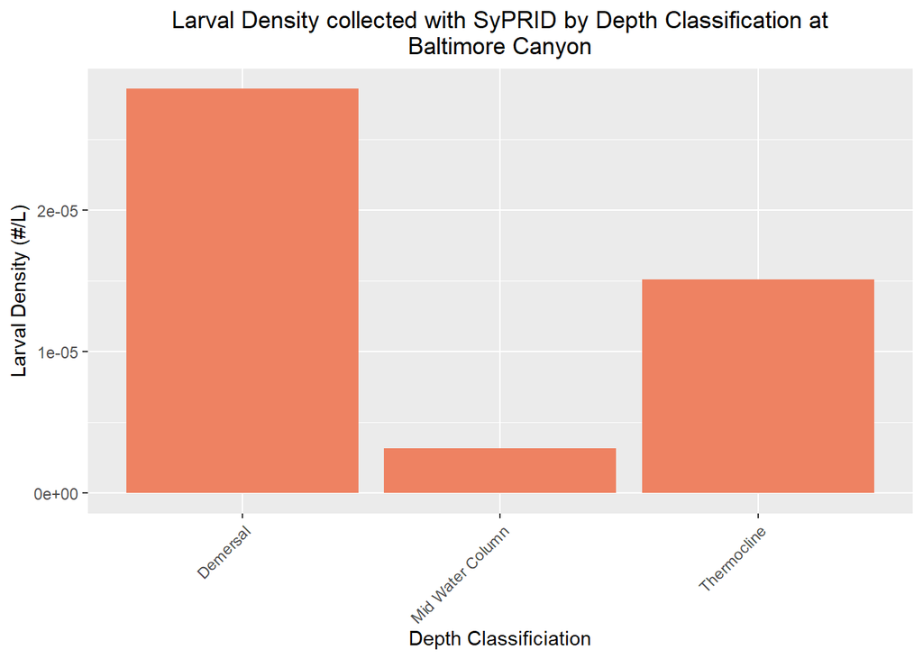

```r
Den(BaltimoreCanyon,"Baltimore Canyon")
```

### Blake Ridge

#### Volume Sampled

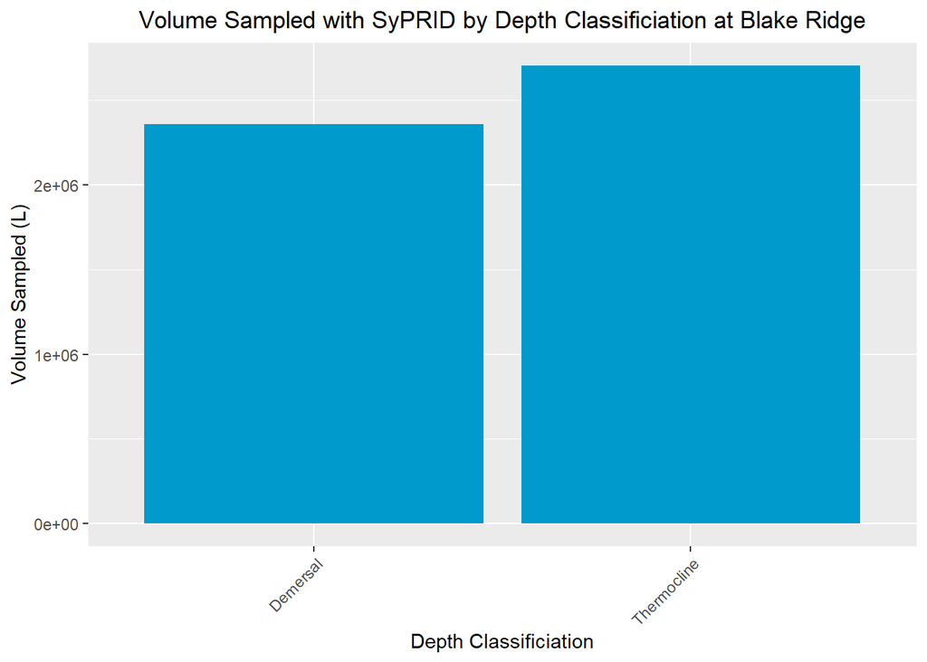

```r
Vol(BlakeRidge, "Blake Ridge")
```

#### Larvae Collected

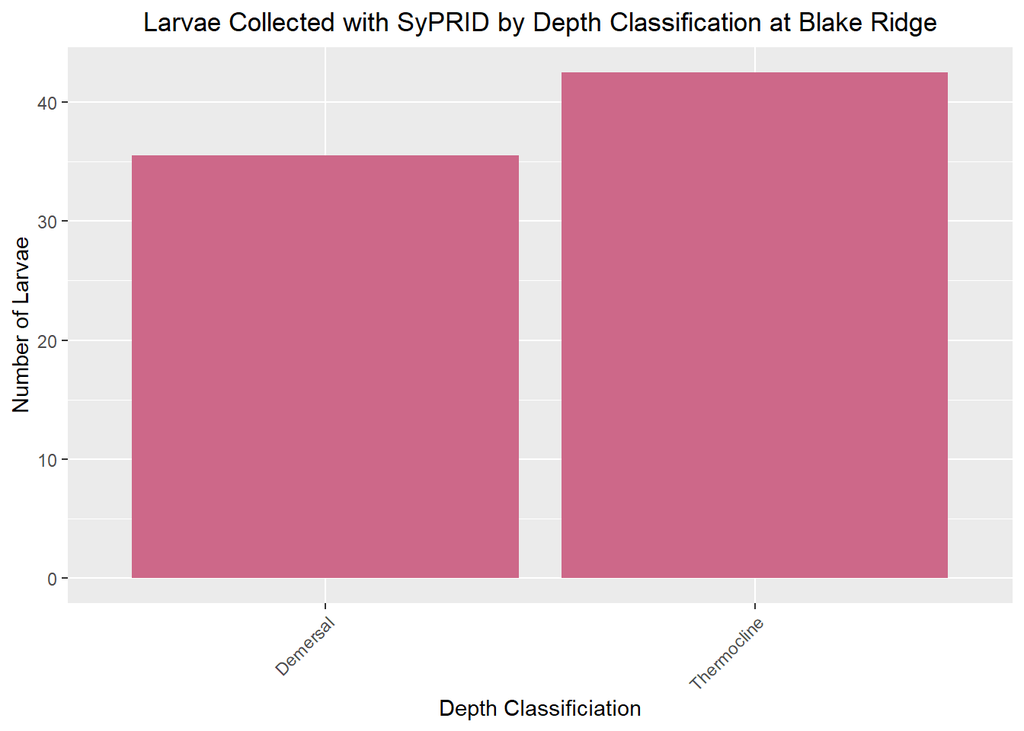

```r
Lar(BlakeRidge, "Blake Ridge")
```

#### Larval Density

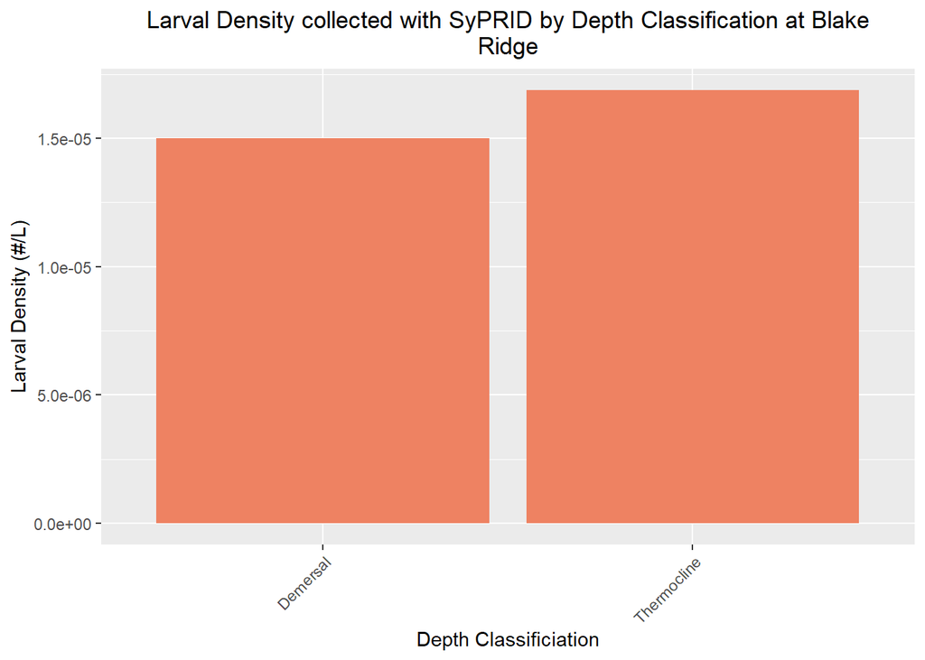

```r
Den(BlakeRidge, "Blake Ridge")
```

### Brine Pool

#### Volume Sampled

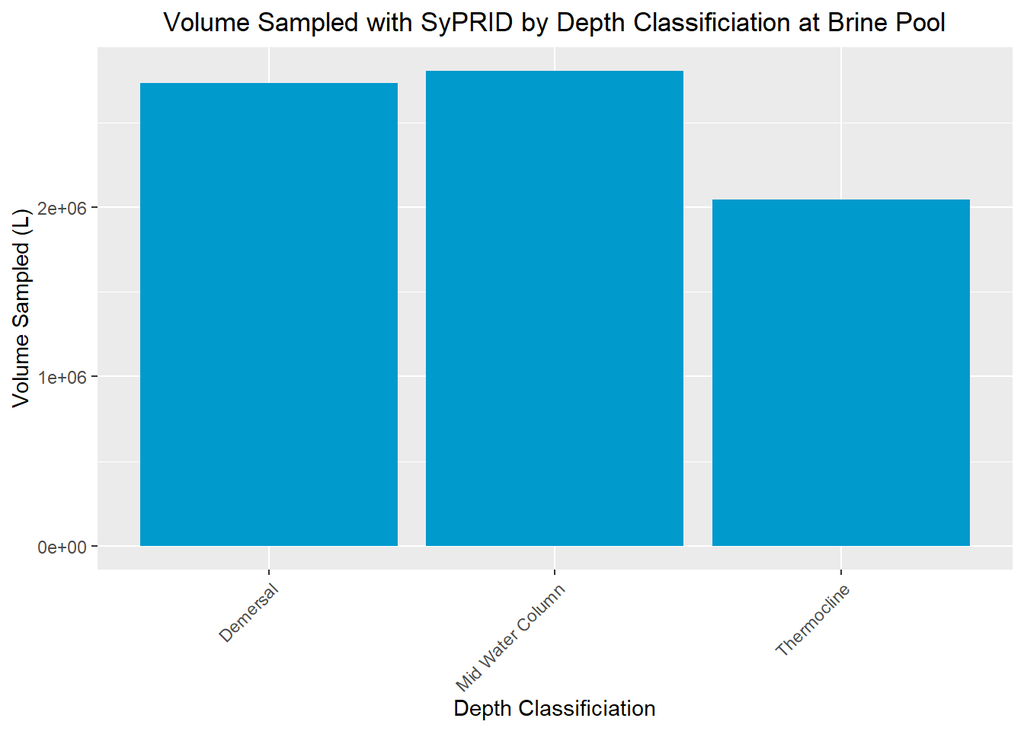

```r
Vol(BrinePool, "Brine Pool")
```

#### Larvae Collected

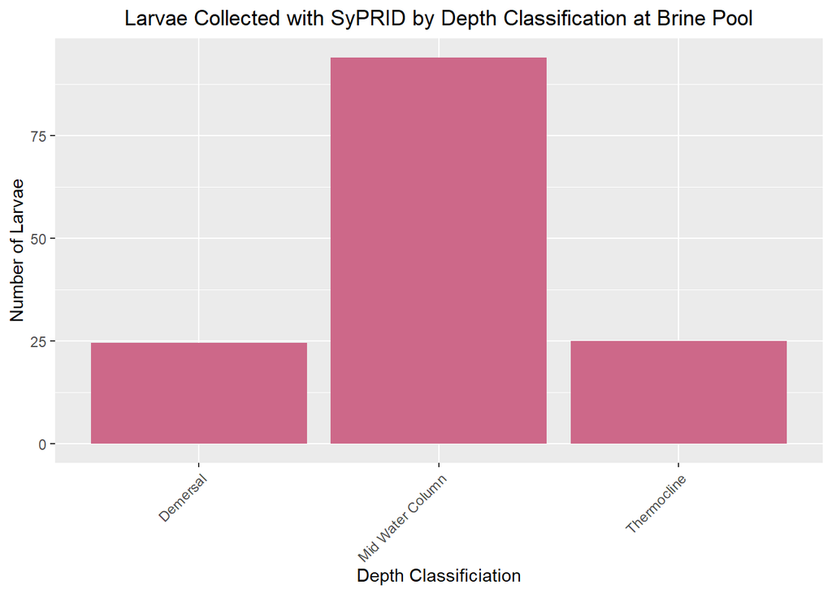

```r
Lar(BrinePool, "Brine Pool")
```

#### Larval Density

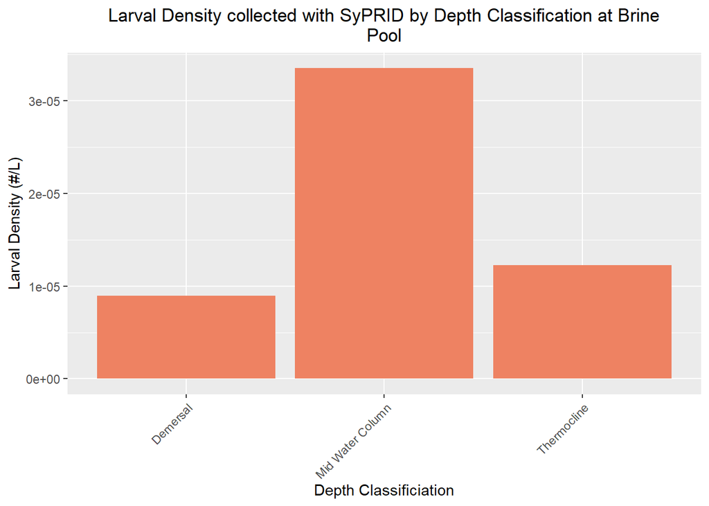

```r
Den(BrinePool, "Brine Pool")
```

### Bush Hill

#### Volume Sampled

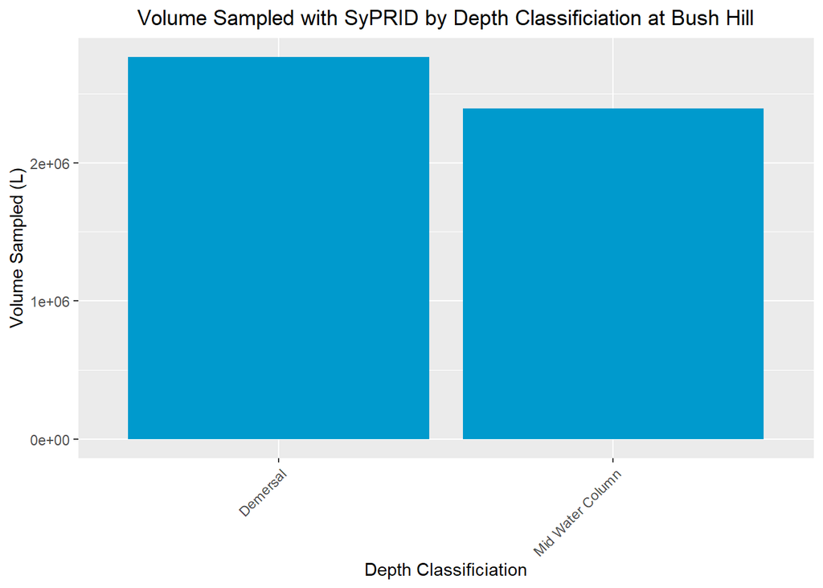

```r
Vol(BushHill, "Bush Hill")
```

#### Larvae Collected

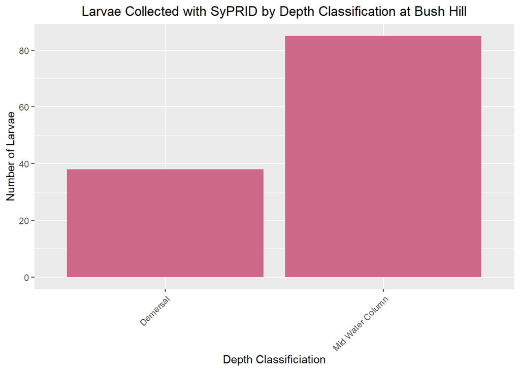

```r
Lar(BushHill, "Bush Hill")
```

#### Larval Density

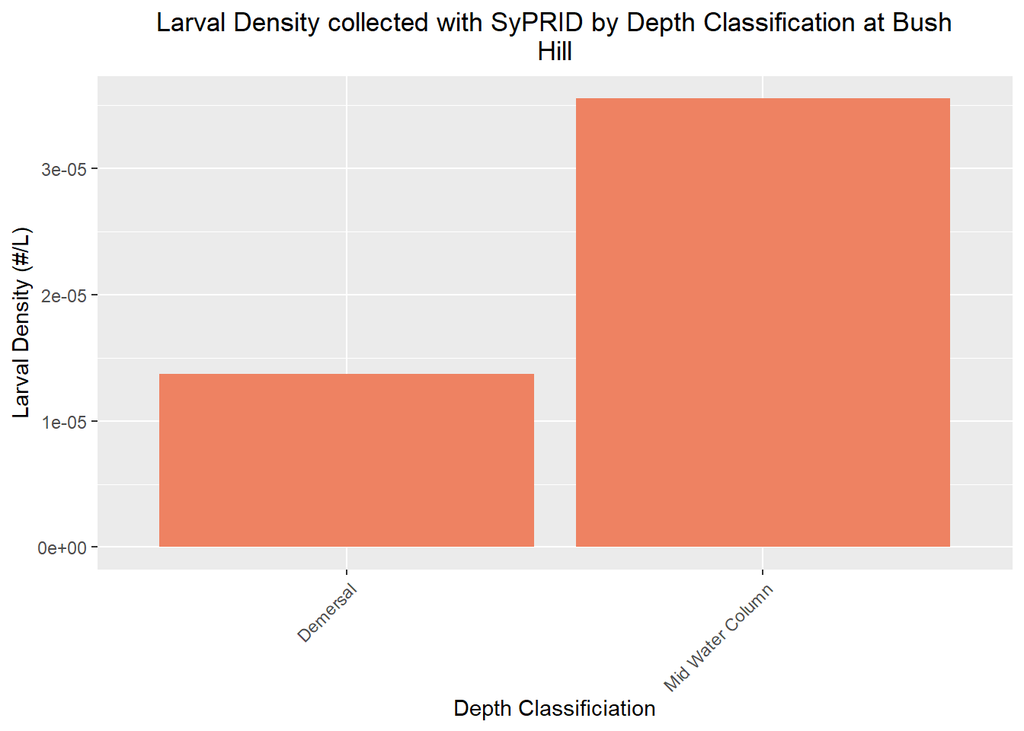

```r
Den(BushHill, "Bush Hill")
```

### Chincoteague

#### Volume Sampled

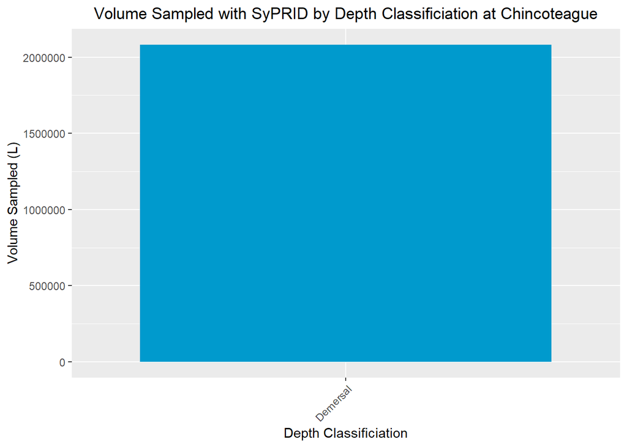

```r
Vol(Chincoteague, "Chincoteague")
```

#### Larvae Collected

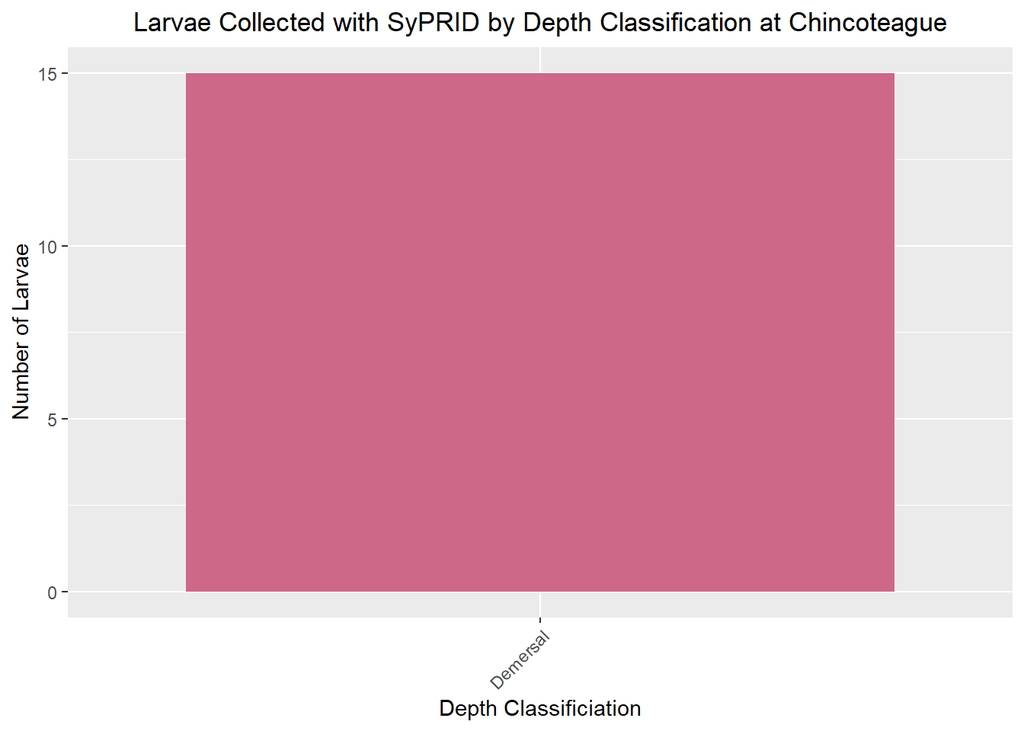

```r
Lar(Chincoteague, "Chincoteague")
```

#### Larval Density

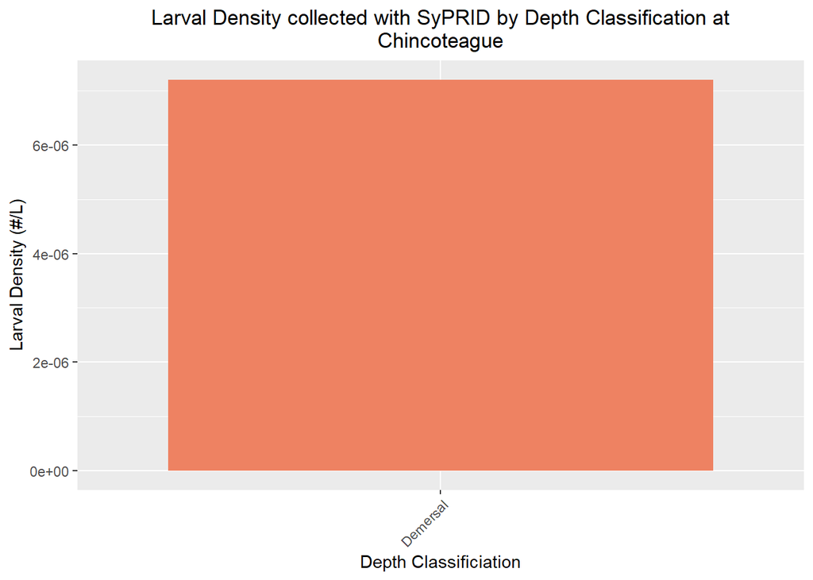

```r
Den(Chincoteague, "Chincoteague")
```

### Florida Escarpment

#### Volume Sampled

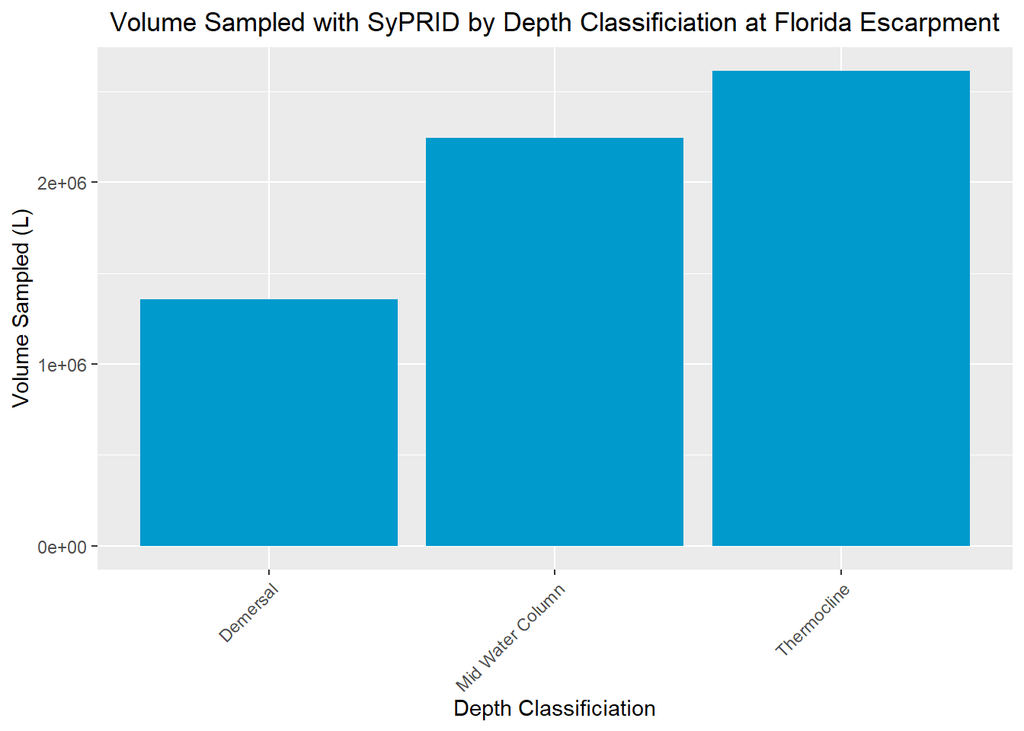

```r
Vol(FloridaEscarpment, "Florida Escarpment")
```

#### Larvae Collected

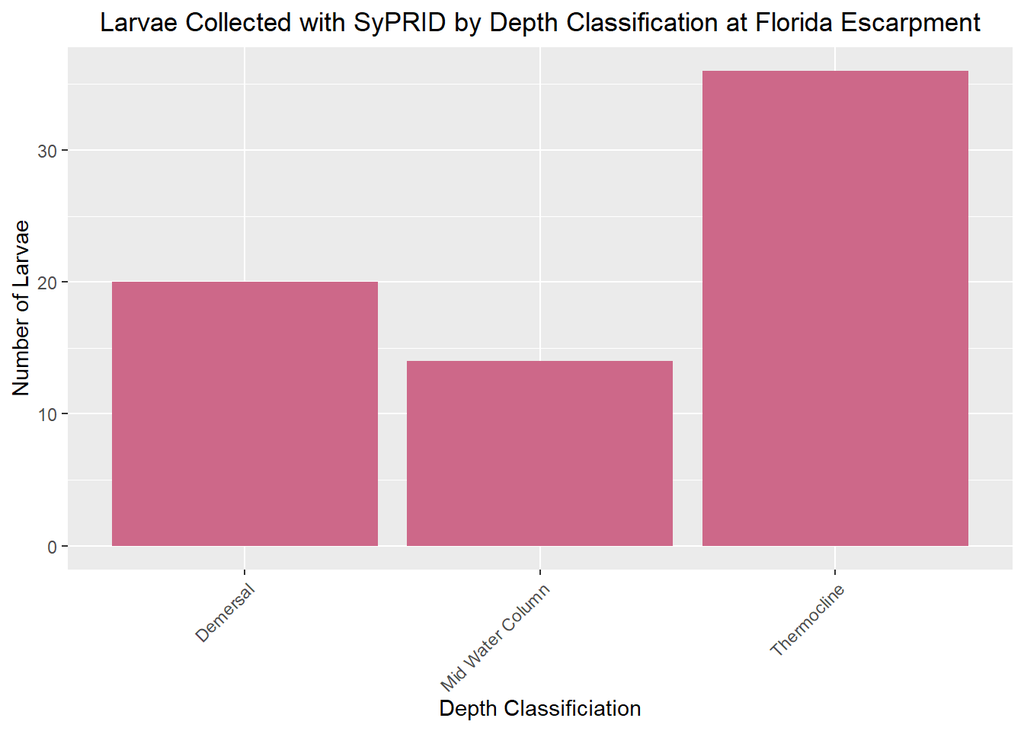

```r
Lar(FloridaEscarpment, "Florida Escarpment")
```

#### Larval Density

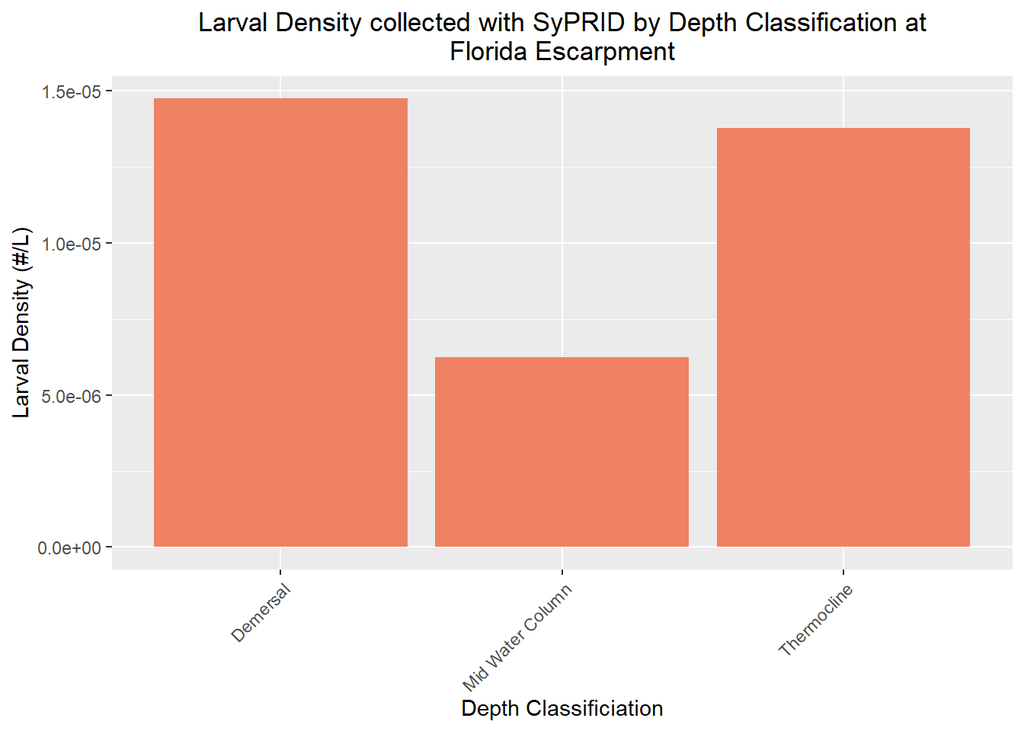

```r
Den(FloridaEscarpment, "Florida Escarpment")
```

### Green Canyon 234

#### Volume Sampled

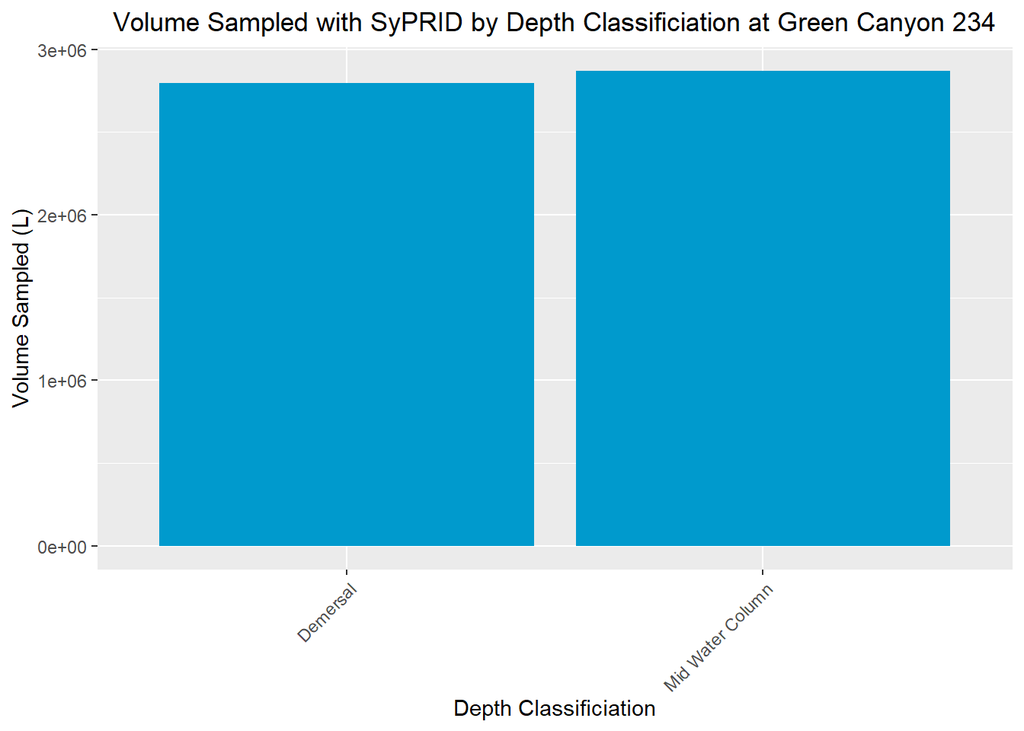

```r
Vol(GC234, "Green Canyon 234")
```

#### Larvae Collected

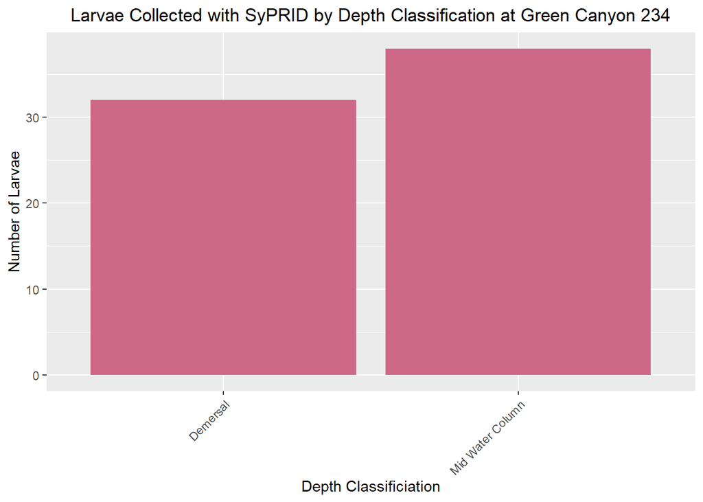

```r
Lar(GC234, "Green Canyon 234")
```

#### Larval Density

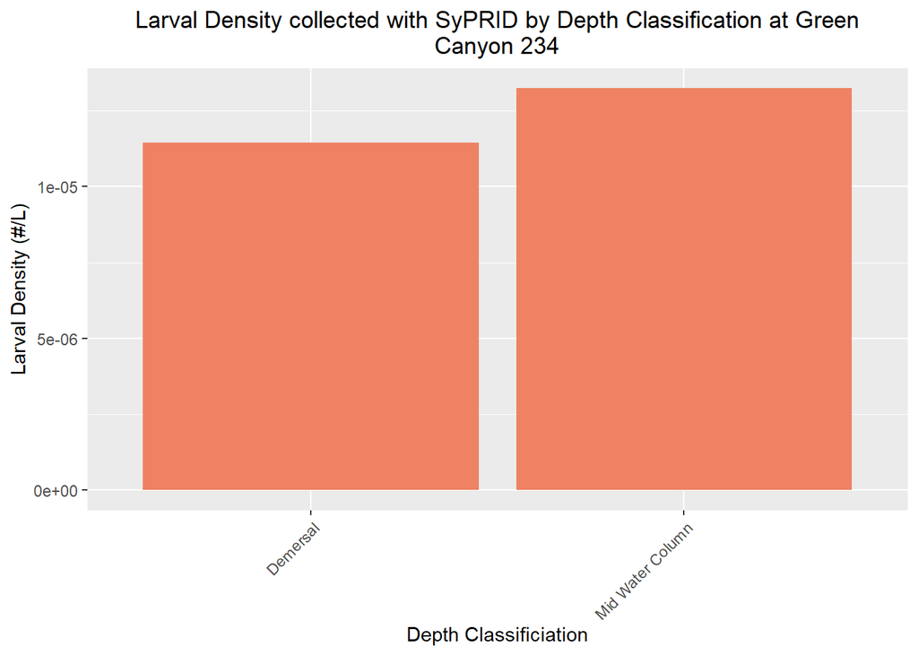

```r
Den(GC234, "Green Canyon 234")
```

### Mississippi Canyon

#### Volume Sampled

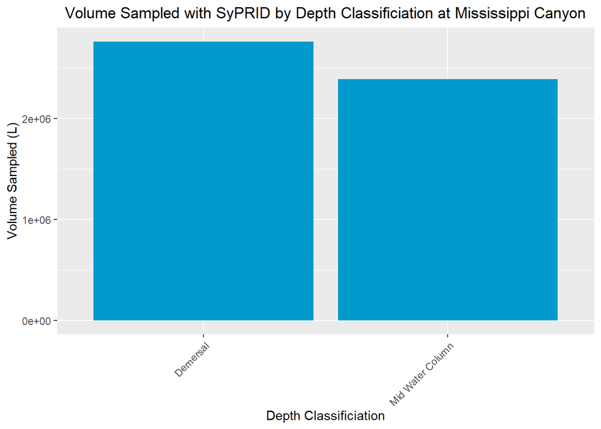

```r
Vol(MississippiCanyon, "Mississippi Canyon")
```

#### Larvae Collected

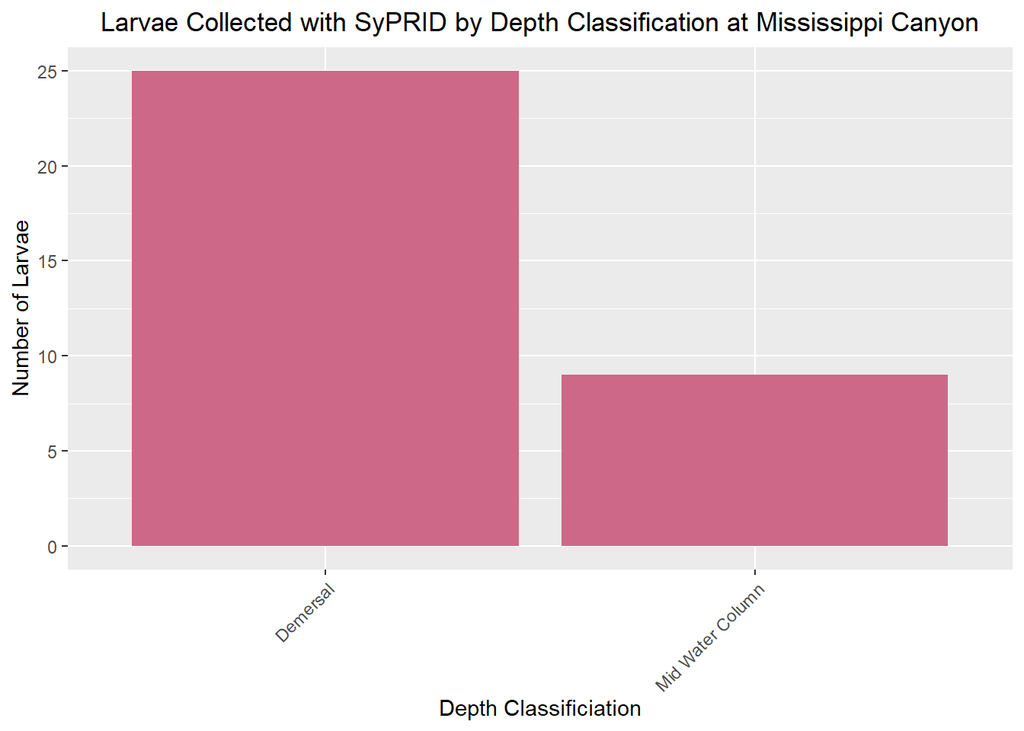

```r
Lar(MississippiCanyon, "Mississippi Canyon")
```